# Over-representation and enrichment analysis: GO and KEGG

EBI Cancer Genomics & Transcriptomics 2025

Alexey Larionov

16 Apr 2025

# Summary

Over-representation and Gene Sets Enrichment analyses are used for functional interpretation of differentially expressed genes lists.

# Start section

Install and load libraries

```r
#install.packages("readr")
#install.packages("dplyr")
#install.packages("stringi")
#BiocManager::install("org.Hs.eg.db")
#BiocManager::install("clusterProfiler")
#BiocManager::install("ggkegg")


# load packages
library(readr)
library(dplyr)
library(stringi)
library(org.Hs.eg.db)
library(clusterProfiler)
library(ggkegg)
```

Clear environment

```r
# Time stamp
Sys.time()
```

```
## [1] "2025-04-06 21:23:44 UTC"
```

```r
rm(list=ls())
graphics.off()
```

# 1. Import and prepare data

## 1.1 Import DESeq2 results

These results were generated during the previous step of the practical session.

```r
base_folder="/home/alexey/bulk-rnaseq/short-reads"
deseq2_output <- file.path(base_folder,"data","deseq_gene_lists","DESeq2_FDR_0.05_2x_FC_genes.txt")

# Import all genes ranked by p-values from DeSeq2 analysis
# readr::read_tsv  provides additional functionality when reading tsv files
genes_raw.df <- readr::read_tsv(file = deseq2_output)

# Explore data
class(genes_raw.df)
```

```
## [1] "spec_tbl_df" "tbl_df"      "tbl"         "data.frame"
```

```r
dim(genes_raw.df)
```

```
## [1] 19618     5
```

```r
head(genes_raw.df)
```

```
## # A tibble: 6 × 5
##   gene_id            gene_name baseMean log2FoldChange     padj
##   <chr>              <chr>        <dbl>          <dbl>    <dbl>
## 1 ENSG00000130294.18 KIF1A       42564.          11.1  1.30e-57
## 2 ENSG00000075340.23 ADD2         6060.           9.96 2.54e-41
## 3 ENSG00000105971.15 CAV2         9139.          -8.36 9.26e-38
## 4 ENSG00000167644.12 C19orf33     1721.          -9.05 2.28e-30
## 5 ENSG00000069188.17 SDK2         1195.           8.98 9.94e-30
## 6 ENSG00000159164.10 SV2A         3426.           7.56 2.17e-26
```

```r
tail(genes_raw.df)
```

```
## # A tibble: 6 × 5
##   gene_id            gene_name       baseMean log2FoldChange  padj
##   <chr>              <chr>              <dbl>          <dbl> <dbl>
## 1 ENSG00000290613.1  LPAL2               56.4          -3.35  1.00
## 2 ENSG00000130720.13 FIBCD1             967.           -3.36  1.00
## 3 ENSG00000293176.1  RPSAP52            156.           -3.48  1.00
## 4 ENSG00000176046.9  NUPR1             6064.           -3.50  1.00
## 5 ENSG00000277011.1  ENSG00000277011     74.1          -3.53  1.00
## 6 ENSG00000261104.1  ENSG00000261104    407.           -3.64  1.00
```

```r
# Clean-up
rm(deseq2_output)
```

## 1.2 Add Entrez ID

Entrez ID will be needed for KEGG analysis. Note that some Ensembl IDs can not be mapped to Entrez IDs. This is an expected limitation of converting between the different Gene IDs.

```r
# Remove version number from ENSEMBL ids
genes_ensembl_no_version.df <-  genes_raw.df %>%
  mutate(gene_id = stringi::stri_replace_all(gene_id,regex = "\\.(\\d*)$", ""))

head(genes_ensembl_no_version.df)
```

```
## # A tibble: 6 × 5
##   gene_id         gene_name baseMean log2FoldChange     padj
##   <chr>           <chr>        <dbl>          <dbl>    <dbl>
## 1 ENSG00000130294 KIF1A       42564.          11.1  1.30e-57
## 2 ENSG00000075340 ADD2         6060.           9.96 2.54e-41
## 3 ENSG00000105971 CAV2         9139.          -8.36 9.26e-38
## 4 ENSG00000167644 C19orf33     1721.          -9.05 2.28e-30
## 5 ENSG00000069188 SDK2         1195.           8.98 9.94e-30
## 6 ENSG00000159164 SV2A         3426.           7.56 2.17e-26
```

```r
tail(genes_ensembl_no_version.df)
```

```
## # A tibble: 6 × 5
##   gene_id         gene_name       baseMean log2FoldChange  padj
##   <chr>           <chr>              <dbl>          <dbl> <dbl>
## 1 ENSG00000290613 LPAL2               56.4          -3.35  1.00
## 2 ENSG00000130720 FIBCD1             967.           -3.36  1.00
## 3 ENSG00000293176 RPSAP52            156.           -3.48  1.00
## 4 ENSG00000176046 NUPR1             6064.           -3.50  1.00
## 5 ENSG00000277011 ENSG00000277011     74.1          -3.53  1.00
## 6 ENSG00000261104 ENSG00000261104    407.           -3.64  1.00
```

```r
# Get vector of all ENSEMBL IDs in our data set
ensembl_id_vector <- genes_ensembl_no_version.df$gene_id

# Using org.Hs.eg.db find ENTREZ IDs corresponding to our ENSEMBL IDs
ensembl_to_entrez.df <- clusterProfiler::bitr(geneID = ensembl_id_vector,
                                              fromType = "ENSEMBL",
                                              toType = "ENTREZID",
                                              OrgDb = "org.Hs.eg.db")
# Check result
head(ensembl_to_entrez.df)
```

```
##           ENSEMBL ENTREZID
## 1 ENSG00000130294      547
## 2 ENSG00000075340      119
## 3 ENSG00000105971      858
## 4 ENSG00000167644    64073
## 5 ENSG00000069188    54549
## 6 ENSG00000159164     9900
```

```r
# Remove duplicated ENSEMBL IDs appeared after adding ENTREZ IDs
duplicated_ENSEMBL_IDs <- duplicated(ensembl_to_entrez.df$ENSEMBL)
sum(duplicated_ENSEMBL_IDs)
```

```
## [1] 544
```

```r
ensembl_to_entrez.df <- ensembl_to_entrez.df[!duplicated_ENSEMBL_IDs,]

duplicated_ENTREZIDs <- duplicated(ensembl_to_entrez.df$ENTREZID)
sum(duplicated_ENTREZIDs)
```

```
## [1] 36
```

```r
ensembl_to_entrez.df <- ensembl_to_entrez.df[!duplicated_ENTREZIDs,]

sum(duplicated(ensembl_to_entrez.df$ENSEMBL))
```

```
## [1] 0
```

```r
sum(duplicated(ensembl_to_entrez.df$ENTREZID))
```

```
## [1] 0
```

```r
# Rename the ENSEMBL ID column to "gene_id"
# to make it consistent with the source data
# (to allow for easy merging with the original dataframe)
ensembl_to_entrez.df <- ensembl_to_entrez.df %>%
  dplyr::rename("gene_id" = ENSEMBL)

# Check result
head(ensembl_to_entrez.df)
```

```
##           gene_id ENTREZID
## 1 ENSG00000130294      547
## 2 ENSG00000075340      119
## 3 ENSG00000105971      858
## 4 ENSG00000167644    64073
## 5 ENSG00000069188    54549
## 6 ENSG00000159164     9900
```

```r
# Add a column with ENTREZ IDs to our dataset
genes_all.df <- genes_ensembl_no_version.df %>%
  left_join(ensembl_to_entrez.df, by = "gene_id")

# Check result
dim(genes_all.df)
```

```
## [1] 19618     6
```

```r
head(genes_all.df)
```

```
## # A tibble: 6 × 6
##   gene_id         gene_name baseMean log2FoldChange     padj ENTREZID
##   <chr>           <chr>        <dbl>          <dbl>    <dbl> <chr>
## 1 ENSG00000130294 KIF1A       42564.          11.1  1.30e-57 547
## 2 ENSG00000075340 ADD2         6060.           9.96 2.54e-41 119
## 3 ENSG00000105971 CAV2         9139.          -8.36 9.26e-38 858
## 4 ENSG00000167644 C19orf33     1721.          -9.05 2.28e-30 64073
## 5 ENSG00000069188 SDK2         1195.           8.98 9.94e-30 54549
## 6 ENSG00000159164 SV2A         3426.           7.56 2.17e-26 9900
```

```r
# Clean-up (remove unneeded interim data)
rm(genes_raw.df, genes_ensembl_no_version.df,
   ensembl_to_entrez.df, ensembl_id_vector,
   duplicated_ENSEMBL_IDs, duplicated_ENTREZIDs)
```

# 2. GSEA

## 2.1 Order by fold change

During DESeq analysis, we sorted our gene list by adjusted p-value. Although it could be used for GSEA, it is more common to order genes by fold change, or by a combination of fold change and p-value, for instance: *lfc / padj* .

In the analysis below we will order genes **by fold change**.

```r
genes_all.df <- genes_all.df %>%
  arrange(desc(log2FoldChange))

# Check result
head(genes_all.df)
```

```
## # A tibble: 6 × 6
##   gene_id         gene_name       baseMean log2FoldChange     padj ENTREZID
##   <chr>           <chr>              <dbl>          <dbl>    <dbl> <chr>
## 1 ENSG00000101180 HRH3                694.           13.0 2.60e- 6 11255
## 2 ENSG00000149295 DRD2               2423.           12.9 6.16e- 6 1813
## 3 ENSG00000185518 SV2B               2203.           12.7 1.25e- 6 9899
## 4 ENSG00000286190 ENSG00000286190    1027.           12.6 6.08e-16 728392
## 5 ENSG00000152932 RAB3C               946.           11.7 3.63e- 8 115827
## 6 ENSG00000107295 SH3GL2              566.           11.7 5.17e- 6 6456
```

```r
tail(genes_all.df)
```

```
## # A tibble: 6 × 6
##   gene_id         gene_name       baseMean log2FoldChange     padj ENTREZID
##   <chr>           <chr>              <dbl>          <dbl>    <dbl> <chr>
## 1 ENSG00000170477 KRT4               3419.          -10.3 2.69e- 7 3851
## 2 ENSG00000256615 ENSG00000256615     154.          -10.6 1.68e- 6 <NA>
## 3 ENSG00000163993 S100P              9717.          -10.8 1.29e- 6 6286
## 4 ENSG00000153292 ADGRF1            10663.          -11.3 1.25e-16 266977
## 5 ENSG00000138271 GPR87               838.          -12.1 1.20e- 8 53836
## 6 ENSG00000087128 TMPRSS11E           495.          -12.3 4.31e- 9 28983
```

## 2.2 GO

The input data for Gene Set Enrichment Analysis (GSEA) should be provided as sorted vectors presenting some numeric feature, such as log fold changes, p-values or others. These vectors must be named by the gene IDs. However, different types of analysis may need different IDs. Thus, **GO enrichment** needs **Ensembl IDs**, while **KEGG enrichment** requires **Entrez IDs** as the gene names.

```r
# Get the sorted log-fold change for GO GSEA
ensembl_gene_list <- genes_all.df$log2FoldChange

# Add Ensembl IDs as names for GO enrichment
names(ensembl_gene_list) <- genes_all.df$gene_id

# Carry out GO sets enrichment analysis
go_gsea <- gseGO(geneList = ensembl_gene_list,
                 OrgDb = org.Hs.eg.db,
                 pvalueCutoff = 0.05,
                 pAdjustMethod = "BH",
                 keyType = "ENSEMBL")

# Explore result
go_gsea.df <- as.data.frame(go_gsea)
colnames(go_gsea.df)
```

```
##  [1] "ID"              "Description"     "setSize"         "enrichmentScore" "NES"             "pvalue"          "p.adjust"        "qvalue"          "rank"            "leading_edge"    "core_enrichment"
```

```r
go_gsea.df <- go_gsea.df %>%
  dplyr::select(ID,Description,setSize,enrichmentScore,p.adjust) %>%
  arrange(p.adjust)
head(go_gsea.df, 10)
```

```
##                    ID                                  Description setSize enrichmentScore     p.adjust
## GO:0051607 GO:0051607                    defense response to virus     244      -0.5672027 2.900526e-08
## GO:0006836 GO:0006836                   neurotransmitter transport     160       0.5992098 2.900526e-08
## GO:0050804 GO:0050804 modulation of chemical synaptic transmission     357       0.5418238 2.900526e-08
## GO:0099177 GO:0099177       regulation of trans-synaptic signaling     358       0.5408079 2.900526e-08
## GO:0008544 GO:0008544                        epidermis development     246      -0.5321494 2.900526e-08
## GO:0009615 GO:0009615                            response to virus     326      -0.5152301 2.900526e-08
## GO:0099504 GO:0099504                       synaptic vesicle cycle     190       0.5641530 2.900526e-08
## GO:0099003 GO:0099003        vesicle-mediated transport in synapse     222       0.5477481 2.900526e-08
## GO:0019221 GO:0019221          cytokine-mediated signaling pathway     345      -0.5064776 2.900526e-08
## GO:0050808 GO:0050808                         synapse organization     439       0.4974657 2.900526e-08
```

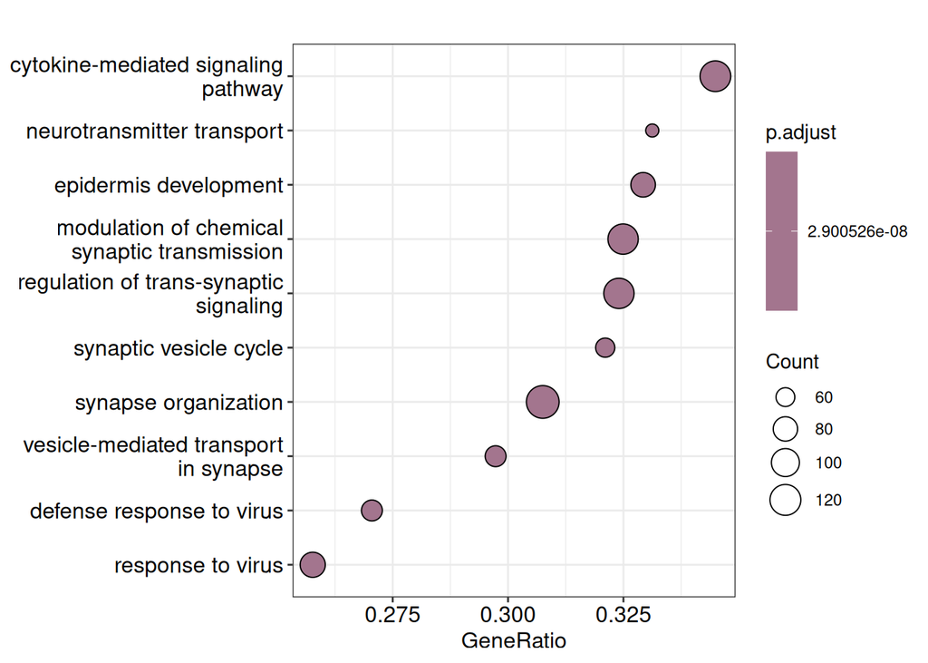

```r
# Plot GO enrichment results
dotplot(go_gsea)
```

```r
# Clean-up
rm(ensembl_gene_list)
```

## 2.3 KEGG

**KEGG enrichment** analysis requires **Entrez IDs** as the gene names.

```r
# Remove rows with missed entrez ids (appr 20% of rows)
filtered_genes_all.df <- genes_all.df %>% filter(!is.na(ENTREZID))

# Get the sorted log-fold changes for GSEA
entrez_gene_list <- filtered_genes_all.df$log2FoldChange

# Add ENTREZID as names for KEGG enrichment
names(entrez_gene_list) <- filtered_genes_all.df$ENTREZID

# Carry out KEGG pathways enrichment analysis
kegg_gsea <- gseKEGG(geneList = entrez_gene_list,
                     organism = 'hsa',
                     pvalueCutoff = 0.05)

# Explore result
kegg_gsea.df <- as.data.frame(kegg_gsea)
colnames(kegg_gsea.df)
```

```
##  [1] "ID"              "Description"     "setSize"         "enrichmentScore" "NES"             "pvalue"          "p.adjust"        "qvalue"          "rank"            "leading_edge"    "core_enrichment"
```

```r
kegg_gsea.df <- kegg_gsea.df %>%
  dplyr::select(ID,Description,setSize,enrichmentScore,p.adjust) %>%
  arrange(p.adjust)
head(kegg_gsea.df, 10)
```

```
##                ID                            Description setSize enrichmentScore     p.adjust
## hsa05323 hsa05323                   Rheumatoid arthritis      60      -0.6811943 4.896586e-05
## hsa05164 hsa05164                            Influenza A     120      -0.5696902 6.026500e-05
## hsa04668 hsa04668                  TNF signaling pathway      99      -0.5908950 7.321815e-05
## hsa04060 hsa04060 Cytokine-cytokine receptor interaction     137      -0.5293536 1.110509e-04
## hsa04621 hsa04621    NOD-like receptor signaling pathway     134      -0.5275047 3.100719e-04
## hsa04725 hsa04725                    Cholinergic synapse      79       0.6054429 5.329412e-04
## hsa04630 hsa04630             JAK-STAT signaling pathway     103      -0.5446076 6.240895e-04
## hsa05321 hsa05321             Inflammatory bowel disease      38      -0.6996979 6.674412e-04
## hsa05418 hsa05418 Fluid shear stress and atherosclerosis     113      -0.5209257 6.674412e-04
## hsa05168 hsa05168       Herpes simplex virus 1 infection     141      -0.4993801 1.131440e-03
```

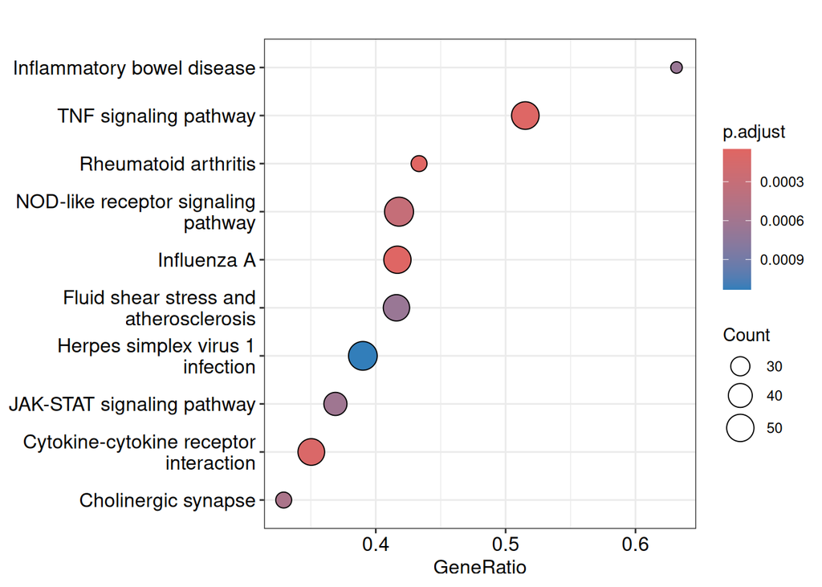

```r
# Plot enrichment results
dotplot(kegg_gsea)
```

```r
# Clean-up
rm(filtered_genes_all.df, entrez_gene_list)
```

# 3. Over-representation

## 3.1 Select Differentially Expressed Genes

Over-representation analysis requires a list of Differentially Expressed Genes (DEGs).

```r
# Select DEGs
# arbitrary criteria: padj < 0.01 and Fold Change > 2x
degs_0.01_2x_entrez.df <- genes_all.df %>%
  filter(padj <= 0.01, abs(log2FoldChange) >= 1)

dim(degs_0.01_2x_entrez.df)
```

```
## [1] 671   6
```

```r
head(degs_0.01_2x_entrez.df)
```

```
## # A tibble: 6 × 6
##   gene_id         gene_name       baseMean log2FoldChange     padj ENTREZID
##   <chr>           <chr>              <dbl>          <dbl>    <dbl> <chr>
## 1 ENSG00000101180 HRH3                694.           13.0 2.60e- 6 11255
## 2 ENSG00000149295 DRD2               2423.           12.9 6.16e- 6 1813
## 3 ENSG00000185518 SV2B               2203.           12.7 1.25e- 6 9899
## 4 ENSG00000286190 ENSG00000286190    1027.           12.6 6.08e-16 728392
## 5 ENSG00000152932 RAB3C               946.           11.7 3.63e- 8 115827
## 6 ENSG00000107295 SH3GL2              566.           11.7 5.17e- 6 6456
```

```r
tail(degs_0.01_2x_entrez.df)
```

```
## # A tibble: 6 × 6
##   gene_id         gene_name       baseMean log2FoldChange     padj ENTREZID
##   <chr>           <chr>              <dbl>          <dbl>    <dbl> <chr>
## 1 ENSG00000170477 KRT4               3419.          -10.3 2.69e- 7 3851
## 2 ENSG00000256615 ENSG00000256615     154.          -10.6 1.68e- 6 <NA>
## 3 ENSG00000163993 S100P              9717.          -10.8 1.29e- 6 6286
## 4 ENSG00000153292 ADGRF1            10663.          -11.3 1.25e-16 266977
## 5 ENSG00000138271 GPR87               838.          -12.1 1.20e- 8 53836
## 6 ENSG00000087128 TMPRSS11E           495.          -12.3 4.31e- 9 28983
```

## 3.2 GO

```r
# Create list of DEGs' Ensembl IDs
degs_ensembl_gene_list <- degs_0.01_2x_entrez.df$gene_id

# carry out GO over-representation analysis
go_ora <- enrichGO(gene = degs_ensembl_gene_list,
                   OrgDb = org.Hs.eg.db,
                   pvalueCutoff = 0.05,
                   pAdjustMethod = "BH",
                   keyType = "ENSEMBL")

# Save result to data frame
go_ora.df <- as.data.frame(go_ora)
head(go_ora.df, 10)
```

```
##                    ID                                      Description GeneRatio   BgRatio RichFactor FoldEnrichment   zScore       pvalue     p.adjust       qvalue                                                                                                                                     …
## GO:0022843 GO:0022843 voltage-gated monoatomic cation channel activity    17/502 142/21348 0.11971831       5.091128 7.590438 4.219673e-08 2.928453e-05 2.536245e-05                                                                                                                                     …
## GO:0005261 GO:0005261               monoatomic cation channel activity    27/502 353/21348 0.07648725       3.252689 6.622768 8.988787e-08 3.119109e-05 2.701367e-05                                                                                 ENSG00000177301/ENSG00000163873/ENSG00000075043/ENSG…
## GO:0005216 GO:0005216                  monoatomic ion channel activity    32/502 481/21348 0.06652807       2.829166 6.296577 1.483620e-07 3.432107e-05 2.972445e-05 ENSG00000177301/ENSG00000163873/ENSG00000075043/ENSG00000153…    32
## GO:0005244 GO:0005244    voltage-gated monoatomic ion channel activity    18/502 180/21348 0.10000000       4.252590 6.800401 2.718860e-07 4.011731e-05 3.474441e-05                                                                                                                                     …
## GO:0022832 GO:0022832                   voltage-gated channel activity    18/502 182/21348 0.09890110       4.205858 6.740149 3.208633e-07 4.011731e-05 3.474441e-05                                                                                                                                     …
## GO:0005249 GO:0005249         voltage-gated potassium channel activity    13/502  95/21348 0.13684211       5.819333 7.305460 3.468356e-07 4.011731e-05 3.474441e-05                                                                                                                                     …
## GO:0022836 GO:0022836                           gated channel activity    25/502 334/21348 0.07485030       3.183076 6.240173 4.057095e-07 4.022320e-05 3.483611e-05                                                                                                                 ENSG00000177301/ENSG…
## GO:0048306 GO:0048306                calcium-dependent protein binding    12/502  83/21348 0.14457831       6.148322 7.292577 5.340334e-07 4.632740e-05 4.012277e-05                                                                                                                                     …
## GO:0005267 GO:0005267                       potassium channel activity    14/502 123/21348 0.11382114       4.840346 6.628389 1.223836e-06 9.437139e-05 8.173224e-05                                                                                                                                     …
## GO:0005154 GO:0005154         epidermal growth factor receptor binding     7/502  35/21348 0.20000000       8.505179 6.895753 1.448590e-05 1.005321e-03 8.706788e-04                                                                                                                                     …
```

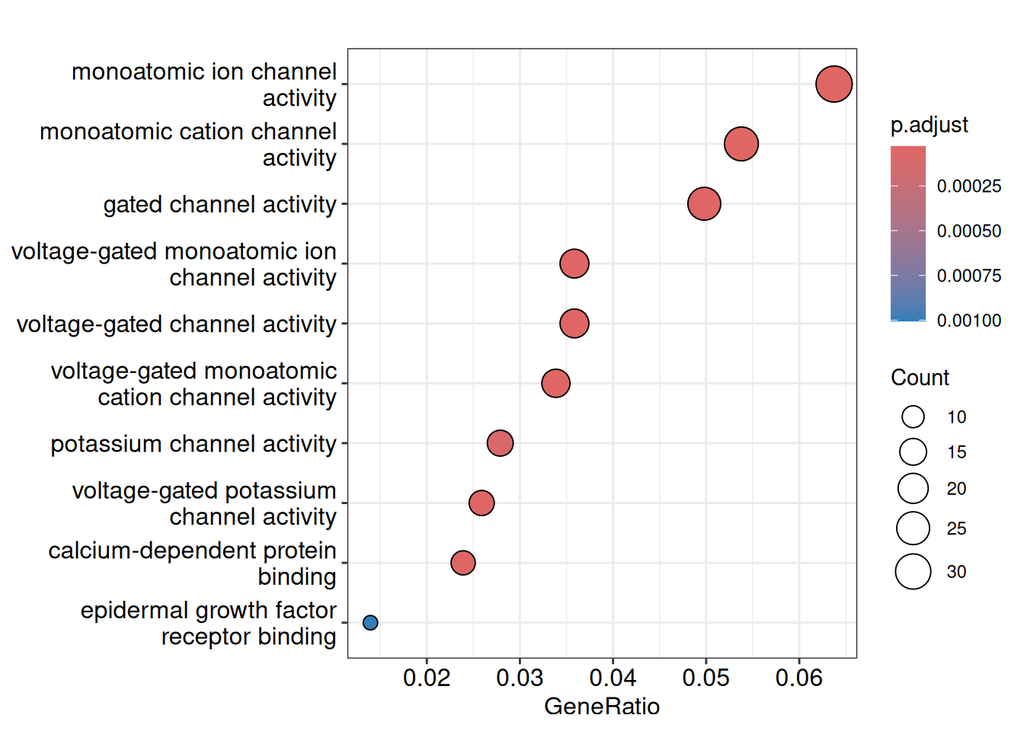

```r
# Plot top results
dotplot(go_ora)
```

```r
# Clean-up
rm(degs_ensembl_gene_list)
```

## 3.3 KEGG

```r
# Create list of Entrez gene IDs
degs_entrez_gene_list <- degs_0.01_2x_entrez.df$ENTREZID

# carry out pathway over-representation analysis
kegg_ora <- enrichKEGG(gene = degs_entrez_gene_list,
                       organism = 'hsa',
                       pvalueCutoff = 0.05,
                       pAdjustMethod = "BH")


# Save result to data frame
kegg_ora.df <- as.data.frame(kegg_ora)
head(kegg_ora.df, 10)
```

```
##                                      category                         subcategory       ID                            Description GeneRatio  BgRatio RichFactor FoldEnrichment   zScore       pvalue     p.adjust       qvalue                                                                           …
## hsa04512 Environmental Information Processing Signaling molecules and interaction hsa04512               ECM-receptor interaction    13/234  89/8545 0.14606742       5.333958 6.896188 7.751184e-07 0.0002077317 0.0001868443                                              9899/9900/1288/5649/3912/1101…
## hsa04510                   Cellular Processes     Cellular community - eukaryotes hsa04510                         Focal adhesion    17/234 203/8545 0.08374384       3.058082 4.979520 3.930802e-05 0.0052672745 0.0047376506                              1288/596/5649/5579/824/3912/1101/3691/7057/39…
## hsa04060 Environmental Information Processing Signaling molecules and interaction hsa04060 Cytokine-cytokine receptor interaction    21/234 298/8545 0.07046980       2.573352 4.638718 6.449279e-05 0.0057613562 0.0051820525 55504/7852/83729/53342/8743/51330/9966/1489/3576/5618/130399/651/652/3557/…
## hsa04151 Environmental Information Processing                 Signal transduction hsa04151             PI3K-Akt signaling pathway    22/234 362/8545 0.06077348       2.219271 3.977499 3.674170e-04 0.0246169392 0.0221417089   1288/2786/596/5979/5649/4902/3912/1101/1021/7097/3691/5618/7057/3914/143…
## hsa05146                       Human Diseases       Infectious disease: parasitic hsa05146                             Amoebiasis    10/234 103/8545 0.09708738       3.545349 4.360690 4.962068e-04 0.0248096933 0.0223150815                                                             1288/5579/3912…
## hsa05031                       Human Diseases                Substance dependence hsa05031                  Amphetamine addiction     8/234  69/8545 0.11594203       4.233866 4.525463 5.554409e-04 0.0248096933 0.0223150815                                                                        841…
## hsa04728                   Organismal Systems                      Nervous system hsa04728                   Dopaminergic synapse    11/234 132/8545 0.08333333       3.043091 3.969275 9.637918e-04 0.0368994561 0.0331892201                                                          1813/84152/774/81…
## hsa04724                   Organismal Systems                      Nervous system hsa04724                  Glutamatergic synapse    10/234 116/8545 0.08620690       3.148025 3.908339 1.259076e-03 0.0374924906 0.0337226251                                                             2899/2914/2912…
## hsa04725                   Organismal Systems                      Nervous system hsa04725                    Cholinergic synapse    10/234 116/8545 0.08620690       3.148025 3.908339 1.259076e-03 0.0374924906 0.0337226251                                                                 3785/774/1…
## hsa04514 Environmental Information Processing Signaling molecules and interaction hsa04514                Cell adhesion molecules    12/234 160/8545 0.07500000       2.738782 3.725337 1.444429e-03 0.0387106938 0.0348183381                                           4684/26047/23705/9378/114798/837…
```

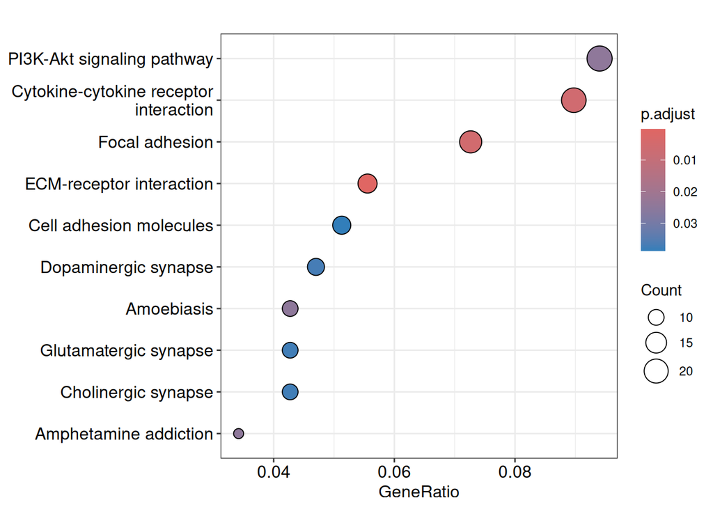

```r
# Plot top results
dotplot(kegg_ora)
```

```r
# Clean-up
rm(degs_entrez_gene_list)
```

# 4. Plot a KEGG pathway

**TNF signalling** (pid=hsa04668) has been found as one of the top enriched KEGG pathways in GSEA analysis. The **ggkegg::rawMap** function can be used to plot the KEGG pathway diagram with our enriched genes highlighted.

[figure not shown]

```r
rawMap(kegg_gsea, pid = "hsa04668")
```

# Save results table to text files

```r
output_folder <- file.path(base_folder,"results","s05_functional_analysis")
dir.create(output_folder)
setwd(output_folder)

write.table(go_gsea.df, file="go_gsea.txt", quote=FALSE, sep="\t", row.names = FALSE, col.names = TRUE)
write.table(go_ora.df, file="go_ora.txt", quote=FALSE, sep="\t", row.names = FALSE, col.names = TRUE)
write.table(kegg_gsea.df, file="kegg_gsea.txt", quote=FALSE, sep="\t", row.names = FALSE, col.names = TRUE)
write.table(kegg_ora.df, file="kegg_ora.txt", quote=FALSE, sep="\t", row.names = FALSE, col.names = TRUE)

# Clean-up
rm(output_folder)
```

# End section

```r
# save image
save.image("Functional_analysis.RData")

# List objects
ls()
```

```
##  [1] "base_folder"            "degs_0.01_2x_entrez.df" "genes_all.df"           "go_gsea"                "go_gsea.df"             "go_ora"                 "go_ora.df"              "kegg_category"          "kegg_gsea"              "kegg_gsea.df"           "kegg_ora"               "kegg_ora.df"
```

```r
# Time stamp
Sys.time()
```

```
## [1] "2025-04-06 21:25:08 UTC"
```